# The Wisdom of Hallucinations: LLMs, Bullshit, and Human-like Thinking

Francesco Veri, Gustavo Kreia Umbelino

2025-09-30

# Define constants

```r
# input data files
HUMAN_PERM_RES_FILE <- "../data/human_perm_test_results.csv"
LLM_PERM_RES_FILE <- "../data/llm_perm_test_results.csv"

# output data files
DELIB_CASES_FILE <- "../data/deliberative_cases.csv"
FIGURES_DIR <- "../figures"
MODELS_RANK <- "../data/models_ri_rank.csv"

# track the number of figures generated
n_fig <- 0


NUM_LLM_ITERATIONS <- 5 # number of LLM responses to use

NUM_LLM_PERMUTATIONS <- 1000 # number of permutations for LLM tests
```

# Load LLM data

We begin by selecting and cleaning LLM data for analysis.

```r
source("01_select_llm_data.R")

# number of min/max iterations per model
models <- llm_data_clean %>%
  group_by(provider, model) %>%
  summarise(total_iterations = n(), .groups = "drop") %>%
  arrange(provider, model)

models %>%
  kable(row.names = TRUE, col.names = c("Provider", "Model", "Total Iterations"), caption = "Models included in the analysis")
```

Models included in the analysis

|  | Provider | Model | Total Iterations |
| --- | --- | --- | --- |
| 1 | anthropic | claude-3-5-haiku-20241022 | 100 |
| 2 | anthropic | claude-3-5-sonnet-20241022 | 100 |
| 3 | anthropic | claude-3-7-sonnet-20250219 | 100 |
| 4 | anthropic | claude-3-7-sonnet-20250219-think=high | 100 |
| 5 | anthropic | claude-3-7-sonnet-20250219-think=low | 100 |
| 6 | anthropic | claude-3-haiku-20240307 | 100 |
| 7 | anthropic | claude-3-opus-20240229 | 100 |
| 8 | anthropic | claude-sonnet-4-20250514 | 100 |
| 9 | anthropic | claude-sonnet-4-5-20250929 | 40 |
| 10 | cohere | command | 100 |
| 11 | cohere | command-a-03-2025 | 100 |
| 12 | cohere | command-r-08-2024 | 100 |
| 13 | cohere | command-r7b-12-2024 | 100 |
| 14 | cohere | command-r7b-12-2024-t=1 | 100 |
| 15 | deepseek | deepseek-chat | 100 |
| 16 | deepseek | deepseek-reasoner | 100 |
| 17 | google | gemini-1.5-flash | 100 |
| 18 | google | gemini-1.5-flash-8b | 100 |
| 19 | google | gemini-1.5-flash-8b-t=1 | 100 |
| 20 | google | gemini-1.5-pro | 100 |
| 21 | google | gemini-2.0-flash | 100 |
| 22 | google | gemini-2.5-pro-preview-03-25 | 100 |
| 23 | google | gemma | 100 |
| 24 | google | gemma2:27b | 100 |
| 25 | ibm | granite3.3 | 100 |
| 26 | meta | llama3.1:405B-turbo | 100 |
| 27 | meta | llama3.3:70b | 100 |
| 28 | meta | llama3:70b | 100 |
| 29 | meta | llama4-maverick | 100 |
| 30 | meta | llama4-scout | 100 |
| 31 | microsoft | phi4 | 100 |
| 32 | mistralai | ministral-3b-latest | 100 |
| 33 | mistralai | ministral-8b-latest | 100 |
| 34 | mistralai | mistral-large-latest | 100 |
| 35 | mistralai | mistral-small-latest | 100 |
| 36 | mistralai | open-mistral-nemo | 100 |
| 37 | mistralai | open-mixtral-8x22b | 100 |
| 38 | openai | gpt-3.5-turbo | 100 |
| 39 | openai | gpt-4 | 100 |
| 40 | openai | gpt-4-turbo | 100 |
| 41 | openai | gpt-4.5-preview | 100 |
| 42 | openai | gpt-4o | 100 |
| 43 | openai | gpt-4o-mini | 100 |
| 44 | openai | gpt-5 | 40 |
| 45 | openai | o1 | 100 |
| 46 | openai | o3-mini | 100 |
| 47 | qwen | qwen-max | 100 |
| 48 | qwen | qwen-plus | 100 |
| 49 | qwen | qwen-turbo | 100 |
| 50 | qwen | qwen1.5-72b-chat | 100 |
| 51 | qwen | qwen2-72b-instruct | 100 |
| 52 | qwen | qwen2.5-72b-instruct | 100 |
| 53 | qwen | qwq-plus | 100 |
| 54 | xai | grok-2-1212 | 100 |
| 55 | xai | grok-3-beta | 100 |
| 56 | xai | grok-3-mini-beta | 100 |
| 57 | xai | grok-3-mini-beta-r=high | 100 |
| 58 | xai | grok-3-mini-beta-r=low | 100 |
| 59 | xai | grok-3-mini-fast-beta | 100 |
| 60 | xai | grok-3-mini-fast-beta-r=high | 100 |
| 61 | xai | grok-3-mini-fast-beta-r=low | 100 |
| 62 | xai | grok-4-fast-non-reasoning | 40 |
| 63 | xai | grok-beta | 100 |

```r
models %>%
  write_csv(paste(FIGURES_DIR, "tab1.csv", sep = "/"))
```

We generated 6120 survey responses from 63 LLMs across 20 surveys. We collected LLM data by prompting each LLM with the same survey questions given to humans in each case study. We prompted each LLM 5 times to capture the variation in LLM responses.

We selected a diverse range of LLM providers, including Anthropic, Cohere, DeepSeek, Google, IBM, Meta, Microsoft, Mistral AI, OpenAI, Qwen, and xAI to capture variation in LLM responses. We selected these LLM providers based on popularity, recommendations from external researchers, and recent work that explores differences across LLMs. The versions used were selected based on availability on LLM repositories, such as ollama and Hugging Face , and availability in proprietary APIs. The goal of this selection is to capture a wide range of LLMs to compare to humans.

For all of the models, unless noted otherwise, we used off-the-shelf, default configurations, with temperature parameter set to zero to reduce the randomness in models’ responses. We also included some variations of the temperature and reasoning effort parameters. These modifications are attached to model names (e.g., t=1 or r=high).

# Run permutation tests

## Human

We then select cases for analysis depending on whether they are consider deliberative or not. To test this, we employ a permutation tests where, for each case study, we permute pre/post deliberation labels. This test is designed to assess whether the difference between pre and post deliberation DRI is random or “truly” deliberative.

```r
if (!file.exists(HUMAN_PERM_RES_FILE)) {
  source("02_human_permutation.R")
}

human_perm_res <- read_csv(HUMAN_PERM_RES_FILE, show_col_types = FALSE)

human_perm_res %>%
  mutate(deliberative = p <= 0.1) %>%
  select(-elapsed_time_s) %>%
  arrange(p) %>%
  kable(caption = "All Cases", digits = 3, row.names = TRUE, col.names = c("Case", "N", "Observed Delta", "Mean Permutation Delta", "p", "Deliebrative (p <= 0.1)"))
```

All Cases

|  | Case | N | Observed Delta | Mean Permutation Delta | p | Deliebrative (p <= 0.1) |
| --- | --- | --- | --- | --- | --- | --- |
| 1 | Activate | 52 | 0.208 | 0.000 | 0.009 | TRUE |
| 2 | FNQCJ | 22 | 0.544 | 0.001 | 0.010 | TRUE |
| 3 | Fremantle | 82 | 0.138 | 0.000 | 0.015 | TRUE |
| 4 | CCPS ACT Deliberative | 62 | 0.105 | 0.001 | 0.051 | TRUE |
| 5 | UBC Bio | 34 | 0.214 | -0.001 | 0.053 | TRUE |
| 6 | Standard | 44 | 0.164 | -0.001 | 0.057 | TRUE |
| 7 | CSIRO WA | 34 | 0.229 | 0.000 | 0.076 | TRUE |
| 8 | Winterthur | 32 | 0.301 | 0.001 | 0.084 | TRUE |
| 9 | Forest Lay Citizen | 18 | 0.197 | -0.001 | 0.100 | TRUE |
| 10 | Zukunft | 126 | 0.081 | -0.001 | 0.119 | FALSE |
| 11 | USTER | 30 | 0.151 | 0.000 | 0.165 | FALSE |
| 12 | WA Citizens | 18 | 0.230 | 0.000 | 0.183 | FALSE |
| 13 | Bellinzona | 16 | 0.189 | -0.003 | 0.212 | FALSE |
| 14 | HGE Deliberative Group | 46 | 0.066 | 0.001 | 0.247 | FALSE |
| 15 | CSIRO NSW | 24 | 0.095 | 0.000 | 0.285 | FALSE |
| 16 | Mayo | 34 | 0.078 | 0.001 | 0.297 | FALSE |
| 17 | CA | 112 | 0.025 | 0.001 | 0.345 | FALSE |
| 18 | Thalwill | 28 | 0.054 | 0.003 | 0.444 | FALSE |
| 19 | BEP | 32 | 0.021 | 0.002 | 0.473 | FALSE |
| 20 | Valsamoggia | 32 | -0.002 | 0.002 | 0.511 | FALSE |
| 21 | WA Stakeholder | 30 | -0.061 | 0.001 | 0.631 | FALSE |
| 22 | Aargau | 32 | -0.104 | 0.001 | 0.659 | FALSE |
| 23 | Forest Stakeholder | 22 | -0.059 | 0.000 | 0.708 | FALSE |
| 24 | Citizen Parliamentarian | 90 | -0.061 | 0.001 | 0.883 | FALSE |

```r
# get an estimate of elapsed time
et <- round(sum(human_perm_res$elapsed_time_s)/60)
```

It takes approx. 23 min to run the human permutation tests.

### Select deliberative cases

```r
# set sugnificance level to 0.1
deliberative_cases <- human_perm_res %>% filter(p <= 0.1)

deliberative_cases %>%
  arrange(p) %>%
  select(-elapsed_time_s) %>%
  knitr::kable(row.names = TRUE,
    caption = "Deliberative Cases", digits = 3)
```

Deliberative Cases

|  | case | N | observed_delta | mean_perm_delta | p |
| --- | --- | --- | --- | --- | --- |
| 1 | Activate | 52 | 0.208 | 0.000 | 0.009 |
| 2 | FNQCJ | 22 | 0.544 | 0.001 | 0.010 |
| 3 | Fremantle | 82 | 0.138 | 0.000 | 0.015 |
| 4 | CCPS ACT Deliberative | 62 | 0.105 | 0.001 | 0.051 |
| 5 | UBC Bio | 34 | 0.214 | -0.001 | 0.053 |
| 6 | Standard | 44 | 0.164 | -0.001 | 0.057 |
| 7 | CSIRO WA | 34 | 0.229 | 0.000 | 0.076 |
| 8 | Winterthur | 32 | 0.301 | 0.001 | 0.084 |
| 9 | Forest Lay Citizen | 18 | 0.197 | -0.001 | 0.100 |

```r
write_csv(deliberative_cases, DELIB_CASES_FILE)

human_perm_res %>%
  mutate(
    N = N/2,
    observed_delta = round(observed_delta, 3),
    mean_perm_delta = round(mean_perm_delta, 3),
    deliberative = p <= 0.1,
  ) %>%
  arrange(p) %>%
  select(-elapsed_time_s) %>%
  write_csv(paste(FIGURES_DIR, "tab2.csv", sep = "/"))
```

For the rest of the analysis, we look only at the 9 deliberative cases listed above. These cases include a total of 380 survey responses (pre/post deliberation) and 190 human participants.

## LLM

We conduct a permutation test to assess whether LLMs reason consistently like humans or randomly. This permutation test is designed to break the link between considerations and policy preferences in the DRI survey responses. As such, for each case and for each model, we add the model as participant in the deliberation, calculate the post-deliberation, individual-level DRI, and record the observed LLM DRI. Then, for each permutation loop, we shuffle the considerations and policy preferences of all participants and record the post-deliberation, individual-level LLM DRI.

```r
if (!file.exists(LLM_PERM_RES_FILE)) {
  source("03_llm_permutation.R")
}

llm_perm_res <- read_csv(LLM_PERM_RES_FILE, show_col_types = FALSE)

## new variable ## dummy significant vs not significant
llm_perm_res$significant <- llm_perm_res$p < 0.05

# get an estimate of elapsed time
et <- round(sum(llm_perm_res$elapsed_time_s) / 60)
```

It took about 125 min to complete LLM permutation test.

Note that we used a lower number of LLM permutations (compared to the previous permutation test) because of the time it takes to run the permutation tests with LLMs. Moreover, in our experience, 1,000 permutations is a good approximation of 10,000.

# Analysis

## Model vs. Case

We begin by visualizing the distribution of observed post-deliberation, individual-level LLM DRI across cases (see Figure below).

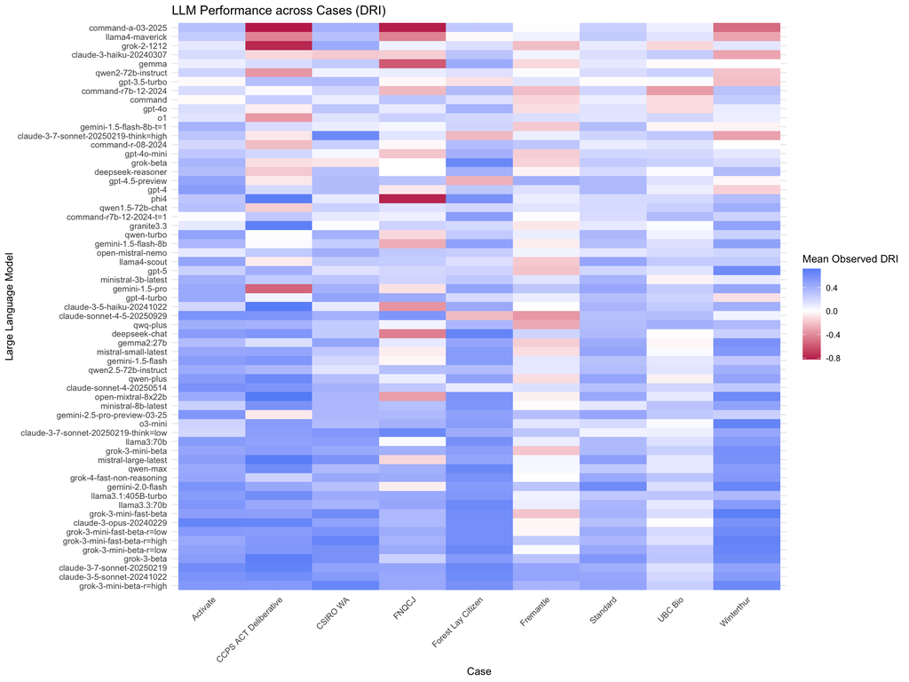

```r
llm_summary <- llm_perm_res %>%
  group_by(model, case) %>%
  summarise(
    mean_dri = mean(observed_dri),
    .groups = "drop"
  )

# this the case perspective heat map on observed DRI
llm_summary %>%
  ggplot(aes(
    x = case,
    y = reorder(model, -mean_dri),
    fill = mean_dri,
  )) +
  geom_tile() +
  scale_fill_gradient2(
    low = "#C22E5A",
    mid = "white",
    high = "#3F83F7",
    midpoint = 0
  ) +
  labs(x = "Case",
       y = "Large Language Model",
       fill = "Mean Observed DRI",
       title = "LLM Performance across Cases (DRI)") +
  theme_minimal(base_size = 10) +
  theme(axis.text.x = element_text(angle = 45, hjust = 1)) -> plot

plot
```

Some of the cases (e.g., CCPS ACT Deliberative, FNQCJ, Fremantle, and UBC Bio) seem to have more variation across models.

### Regressions

We create a model to understand whether case affects significance. We begin with a fixed effects (FE) logistical model. Then, we create a model with random intercept (RI) to check whether it is necessary to account for the impact of each model on cases.

```r
# fixed effects model
fe_cases_model <- glm(significant ~ case, data = llm_perm_res, family = binomial)
summary(fe_cases_model)
```

```
##
## Call:
## glm(formula = significant ~ case, family = binomial, data = llm_perm_res)
##
## Coefficients:
##                           Estimate Std. Error z value Pr(>|z|)
## (Intercept)                 0.1208     0.1129   1.070   0.2847
## caseCCPS ACT Deliberative  -1.0216     0.1679  -6.084 1.18e-09 ***
## caseCSIRO WA                0.1410     0.1602   0.880   0.3787
## caseFNQCJ                  -1.0062     0.1676  -6.002 1.94e-09 ***
## caseForest Lay Citizen     -0.6742     0.1626  -4.146 3.38e-05 ***
## caseFremantle              -0.2161     0.1596  -1.354   0.1757
## caseStandard               -0.3955     0.1603  -2.468   0.0136 *
## caseUBC Bio                -1.5677     0.1826  -8.587  < 2e-16 ***
## caseWinterthur              0.3513     0.1618   2.172   0.0299 *
## ---
## Signif. codes:  0 '***' 0.001 '**' 0.01 '*' 0.05 '.' 0.1 ' ' 1
##
## (Dispersion parameter for binomial family taken to be 1)
##
##     Null deviance: 3852.2  on 2834  degrees of freedom
## Residual deviance: 3632.7  on 2826  degrees of freedom
## AIC: 3650.7
##
## Number of Fisher Scoring iterations: 4
```

```r
# random intercept model
ri_cases_model <- glmmTMB(significant ~ 1 + (1 | model),
                      data = llm_perm_res,
                      family = binomial)

summary(ri_cases_model)
```

```
##  Family: binomial  ( logit )
## Formula:          significant ~ 1 + (1 | model)
## Data: llm_perm_res
##
##       AIC       BIC    logLik -2*log(L)  df.resid
##    3771.8    3783.7   -1883.9    3767.8      2833
##
## Random effects:
##
## Conditional model:
##  Groups Name        Variance Std.Dev.
##  model  (Intercept) 0.2613   0.5112
## Number of obs: 2835, groups:  model, 63
##
## Conditional model:
##             Estimate Std. Error z value Pr(>|z|)
## (Intercept) -0.35469    0.07553  -4.696 2.65e-06 ***
## ---
## Signif. codes:  0 '***' 0.001 '**' 0.01 '*' 0.05 '.' 0.1 ' ' 1
```

```r
icc(ri_cases_model)
```

```
## # Intraclass Correlation Coefficient
##
##     Adjusted ICC: 0.074
##   Unadjusted ICC: 0.074
```

Low ICC suggests that the FE model is good enough. Further tests are needed, but not the goal of this analysis.

## Significance Percentage

We analysed the percentage of significant permutations across models and cases. There are 9 deliberative cases and each model has 5 iterations, resulting in a total of 45 possible significant results.

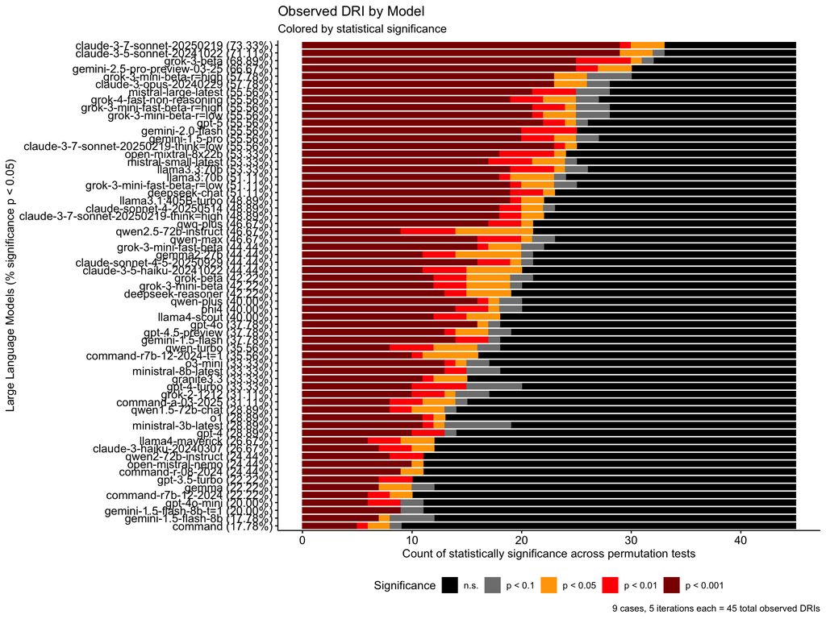

```r
model_sig_summary <- llm_perm_res %>%
  group_by(model) %>%
  summarise(
    total = n(),
    significant = sum(p < 0.05),
    perc_significant = round(100 * significant / total, 2),
    .groups = "drop"
  ) %>%
  mutate(label = paste0(model, " (", sprintf(perc_significant, fmt = '%#.2f'), "%)"))


llm_perm_labeled <- llm_perm_res %>%
  left_join(model_sig_summary, by = "model")

bar <- llm_perm_labeled %>%
  mutate(sign = case_when(
      p < 0.001 ~ "p < 0.001",
      p < 0.01 ~ "p < 0.01",
      p < 0.05 ~ "p < 0.05",
      p < 0.1 ~ "p < 0.1",
      TRUE ~ "n.s."  # use "n.s." instead of empty string
    )) %>%
  group_by(label, sign, perc_significant) %>%
  summarise(count = n(), .groups = "drop") %>%
  arrange(perc_significant)

bar$sign <- factor(bar$sign, levels = c("n.s.", "p < 0.1", "p < 0.05", "p < 0.01", "p < 0.001"))

model_order <- unique(bar$label)

bar %>%
  ggbarplot(
    x = "label",
    y = "count",
    fill = "sign",
    color = "sign",
    #label = count,
    order = model_order,
    title = "Observed DRI by Model",
    subtitle = "Colored by statistical significance",
    caption = "9 cases, 5 iterations each = 45 total observed DRIs",
    xlab = "Large Language Models (% significance p < 0.05)",
    ylab = "Count of statistically significance across permutation tests"
  ) %>% ggpar(orientation = "horiz",
              legend = "bottom",
              legend.title = "Significance") +

  scale_fill_manual(values = c(
    "p < 0.001" = "darkred",
    "p < 0.01" = "red",
    "p < 0.05" = "orange",
    "p < 0.1" = "grey50",
    "n.s." = "black"  # mapped here
  )) + scale_color_manual(values = c(
    "p < 0.001" = "darkred",
    "p < 0.01" = "red",
    "p < 0.05" = "orange",
    "p < 0.1" = "grey50",
    "n.s." = "black"  # mapped here
  ))  -> plot

plot
```

```r
# print summary statistics
get_summary_stats(llm_perm_labeled, type="robust") %>%
  kable(caption = "Summary of Robust Statistics")
```

Summary of Robust Statistics

| variable | n | median | iqr |
| --- | --- | --- | --- |
| it | 2835 | 3.000 | 2.000 |
| N | 2835 | 17.000 | 10.000 |
| observed_dri | 2835 | 0.366 | 0.456 |
| mean_perm_dri | 2835 | 0.328 | 0.111 |
| p | 2835 | 0.340 | 1.000 |
| elapsed_time_s | 2835 | 2.582 | 0.445 |
| total | 2835 | 45.000 | 0.000 |
| significant.y | 2835 | 19.000 | 11.000 |
| perc_significant | 2835 | 42.220 | 24.440 |

The following table shows the percentage of significant results per model.

```r
model_sig_summary %>%
  select(-label) %>%
  arrange(-significant) %>%
  kable()
```

| model | total | significant | perc_significant |
| --- | --- | --- | --- |
| claude-3-7-sonnet-20250219 | 45 | 33 | 73.33 |
| claude-3-5-sonnet-20241022 | 45 | 32 | 71.11 |
| grok-3-beta | 45 | 31 | 68.89 |
| gemini-2.5-pro-preview-03-25 | 45 | 30 | 66.67 |
| claude-3-opus-20240229 | 45 | 26 | 57.78 |
| grok-3-mini-beta-r=high | 45 | 26 | 57.78 |
| claude-3-7-sonnet-20250219-think=low | 45 | 25 | 55.56 |
| gemini-1.5-pro | 45 | 25 | 55.56 |
| gemini-2.0-flash | 45 | 25 | 55.56 |
| gpt-5 | 45 | 25 | 55.56 |
| grok-3-mini-beta-r=low | 45 | 25 | 55.56 |
| grok-3-mini-fast-beta-r=high | 45 | 25 | 55.56 |
| grok-4-fast-non-reasoning | 45 | 25 | 55.56 |
| mistral-large-latest | 45 | 25 | 55.56 |
| llama3.3:70b | 45 | 24 | 53.33 |
| mistral-small-latest | 45 | 24 | 53.33 |
| open-mixtral-8x22b | 45 | 24 | 53.33 |
| deepseek-chat | 45 | 23 | 51.11 |
| grok-3-mini-fast-beta-r=low | 45 | 23 | 51.11 |
| llama3:70b | 45 | 23 | 51.11 |
| claude-3-7-sonnet-20250219-think=high | 45 | 22 | 48.89 |
| claude-sonnet-4-20250514 | 45 | 22 | 48.89 |
| llama3.1:405B-turbo | 45 | 22 | 48.89 |
| qwen-max | 45 | 21 | 46.67 |
| qwen2.5-72b-instruct | 45 | 21 | 46.67 |
| qwq-plus | 45 | 21 | 46.67 |
| claude-3-5-haiku-20241022 | 45 | 20 | 44.44 |
| claude-sonnet-4-5-20250929 | 45 | 20 | 44.44 |
| gemma2:27b | 45 | 20 | 44.44 |
| grok-3-mini-fast-beta | 45 | 20 | 44.44 |
| deepseek-reasoner | 45 | 19 | 42.22 |
| grok-3-mini-beta | 45 | 19 | 42.22 |
| grok-beta | 45 | 19 | 42.22 |
| llama4-scout | 45 | 18 | 40.00 |
| phi4 | 45 | 18 | 40.00 |
| qwen-plus | 45 | 18 | 40.00 |
| gemini-1.5-flash | 45 | 17 | 37.78 |
| gpt-4.5-preview | 45 | 17 | 37.78 |
| gpt-4o | 45 | 17 | 37.78 |
| command-r7b-12-2024-t=1 | 45 | 16 | 35.56 |
| qwen-turbo | 45 | 16 | 35.56 |
| gpt-4-turbo | 45 | 15 | 33.33 |
| granite3.3 | 45 | 15 | 33.33 |
| ministral-8b-latest | 45 | 15 | 33.33 |
| o3-mini | 45 | 15 | 33.33 |
| command-a-03-2025 | 45 | 14 | 31.11 |
| grok-2-1212 | 45 | 14 | 31.11 |
| gpt-4 | 45 | 13 | 28.89 |
| ministral-3b-latest | 45 | 13 | 28.89 |
| o1 | 45 | 13 | 28.89 |
| qwen1.5-72b-chat | 45 | 13 | 28.89 |
| claude-3-haiku-20240307 | 45 | 12 | 26.67 |
| llama4-maverick | 45 | 12 | 26.67 |
| command-r-08-2024 | 45 | 11 | 24.44 |
| open-mistral-nemo | 45 | 11 | 24.44 |
| qwen2-72b-instruct | 45 | 11 | 24.44 |
| command-r7b-12-2024 | 45 | 10 | 22.22 |
| gemma | 45 | 10 | 22.22 |
| gpt-3.5-turbo | 45 | 10 | 22.22 |
| gemini-1.5-flash-8b-t=1 | 45 | 9 | 20.00 |
| gpt-4o-mini | 45 | 9 | 20.00 |
| command | 45 | 8 | 17.78 |
| gemini-1.5-flash-8b | 45 | 8 | 17.78 |

## Odds-Ratio

To account for chance in the analysis above, we calculate the odds-ratio of a model performing like humans or randomly by first fitting a model to predict significance.

### Model Selection

#### Linear Regression Model

Note that in this model smaller estimates are “better” because smaller p-values are “better”. We begin with this model as a robustness check of further results.

```r
linear_model <- glm(p ~ model, data = llm_perm_res)
summary(linear_model)
```

```
##
## Call:
## glm(formula = p ~ model, data = llm_perm_res)
##
## Coefficients:
##                                            Estimate Std. Error t value Pr(>|t|)
## (Intercept)                                 0.51289    0.06803   7.539 6.39e-14
## modelclaude-3-5-sonnet-20241022            -0.33496    0.09621  -3.481 0.000507
## modelclaude-3-7-sonnet-20250219            -0.31316    0.09621  -3.255 0.001149
## modelclaude-3-7-sonnet-20250219-think=high -0.05176    0.09621  -0.538 0.590678
## modelclaude-3-7-sonnet-20250219-think=low  -0.11269    0.09621  -1.171 0.241610
## modelclaude-3-haiku-20240307                0.15684    0.09621   1.630 0.103184
## modelclaude-3-opus-20240229                -0.17462    0.09621  -1.815 0.069644
## modelclaude-sonnet-4-20250514              -0.12929    0.09621  -1.344 0.179139
## modelclaude-sonnet-4-5-20250929            -0.05420    0.09621  -0.563 0.573261
## modelcommand                                0.23371    0.09621   2.429 0.015201
## modelcommand-a-03-2025                      0.11756    0.09621   1.222 0.221886
## modelcommand-r-08-2024                      0.08036    0.09621   0.835 0.403695
## modelcommand-r7b-12-2024                    0.17860    0.09621   1.856 0.063522
## modelcommand-r7b-12-2024-t=1                0.04122    0.09621   0.428 0.668365
## modeldeepseek-chat                         -0.09111    0.09621  -0.947 0.343744
## modeldeepseek-reasoner                     -0.00880    0.09621  -0.091 0.927132
## modelgemini-1.5-flash                      -0.02636    0.09621  -0.274 0.784163
## modelgemini-1.5-flash-8b                    0.10893    0.09621   1.132 0.257653
## modelgemini-1.5-flash-8b-t=1                0.17800    0.09621   1.850 0.064416
## modelgemini-1.5-pro                        -0.13149    0.09621  -1.367 0.171856
## modelgemini-2.0-flash                      -0.12244    0.09621  -1.273 0.203261
## modelgemini-2.5-pro-preview-03-25          -0.20296    0.09621  -2.109 0.035000
## modelgemma                                  0.15351    0.09621   1.596 0.110714
## modelgemma2:27b                            -0.03282    0.09621  -0.341 0.733028
## modelgpt-3.5-turbo                          0.17622    0.09621   1.832 0.067126
## modelgpt-4                                  0.10600    0.09621   1.102 0.270687
## modelgpt-4-turbo                           -0.03553    0.09621  -0.369 0.711923
## modelgpt-4.5-preview                       -0.03898    0.09621  -0.405 0.685427
## modelgpt-4o                                 0.06738    0.09621   0.700 0.483808
## modelgpt-4o-mini                            0.15700    0.09621   1.632 0.102843
## modelgpt-5                                 -0.09167    0.09621  -0.953 0.340810
## modelgranite3.3                             0.07013    0.09621   0.729 0.466110
## modelgrok-2-1212                            0.05933    0.09621   0.617 0.537499
## modelgrok-3-beta                           -0.35149    0.09621  -3.653 0.000264
```

[output cut: 88 more lines]

```
## modelqwen-turbo
## modelqwen1.5-72b-chat
## modelqwen2-72b-instruct                    .
## modelqwen2.5-72b-instruct
## modelqwq-plus
## ---
## Signif. codes:  0 '***' 0.001 '**' 0.01 '*' 0.05 '.' 0.1 ' ' 1
##
## (Dispersion parameter for gaussian family taken to be 0.2082892)
##
##     Null deviance: 630.58  on 2834  degrees of freedom
## Residual deviance: 577.38  on 2772  degrees of freedom
## AIC: 3662
##
## Number of Fisher Scoring iterations: 2
```

```r
tidy(linear_model) %>%
  mutate(term = gsub("model", "", term)) %>%
  arrange(estimate) %>%
  kable(digits = 3)
```

| term | estimate | std.error | statistic | p.value |
| --- | --- | --- | --- | --- |
| grok-3-beta | -0.351 | 0.096 | -3.653 | 0.000 |
| claude-3-5-sonnet-20241022 | -0.335 | 0.096 | -3.481 | 0.001 |
| claude-3-7-sonnet-20250219 | -0.313 | 0.096 | -3.255 | 0.001 |
| grok-3-mini-beta-r=high | -0.246 | 0.096 | -2.554 | 0.011 |
| grok-3-mini-beta-r=low | -0.206 | 0.096 | -2.139 | 0.033 |
| gemini-2.5-pro-preview-03-25 | -0.203 | 0.096 | -2.109 | 0.035 |
| grok-3-mini-fast-beta-r=high | -0.187 | 0.096 | -1.947 | 0.052 |
| mistral-large-latest | -0.182 | 0.096 | -1.893 | 0.058 |
| claude-3-opus-20240229 | -0.175 | 0.096 | -1.815 | 0.070 |
| llama3.3:70b | -0.166 | 0.096 | -1.726 | 0.085 |
| grok-4-fast-non-reasoning | -0.150 | 0.096 | -1.556 | 0.120 |
| llama3:70b | -0.142 | 0.096 | -1.478 | 0.139 |
| gemini-1.5-pro | -0.131 | 0.096 | -1.367 | 0.172 |
| claude-sonnet-4-20250514 | -0.129 | 0.096 | -1.344 | 0.179 |
| gemini-2.0-flash | -0.122 | 0.096 | -1.273 | 0.203 |
| grok-3-mini-fast-beta-r=low | -0.122 | 0.096 | -1.263 | 0.207 |
| open-mixtral-8x22b | -0.116 | 0.096 | -1.204 | 0.229 |
| claude-3-7-sonnet-20250219-think=low | -0.113 | 0.096 | -1.171 | 0.242 |
| qwen-max | -0.109 | 0.096 | -1.138 | 0.255 |
| mistral-small-latest | -0.108 | 0.096 | -1.117 | 0.264 |
| llama3.1:405B-turbo | -0.097 | 0.096 | -1.009 | 0.313 |
| gpt-5 | -0.092 | 0.096 | -0.953 | 0.341 |
| deepseek-chat | -0.091 | 0.096 | -0.947 | 0.344 |
| ministral-8b-latest | -0.082 | 0.096 | -0.856 | 0.392 |
| grok-3-mini-fast-beta | -0.079 | 0.096 | -0.824 | 0.410 |
| grok-3-mini-beta | -0.062 | 0.096 | -0.641 | 0.522 |
| qwq-plus | -0.056 | 0.096 | -0.580 | 0.562 |
| claude-sonnet-4-5-20250929 | -0.054 | 0.096 | -0.563 | 0.573 |
| claude-3-7-sonnet-20250219-think=high | -0.052 | 0.096 | -0.538 | 0.591 |
| qwen2.5-72b-instruct | -0.044 | 0.096 | -0.461 | 0.645 |
| qwen-plus | -0.042 | 0.096 | -0.440 | 0.660 |
| gpt-4.5-preview | -0.039 | 0.096 | -0.405 | 0.685 |
| gpt-4-turbo | -0.036 | 0.096 | -0.369 | 0.712 |
| gemma2:27b | -0.033 | 0.096 | -0.341 | 0.733 |
| gemini-1.5-flash | -0.026 | 0.096 | -0.274 | 0.784 |
| deepseek-reasoner | -0.009 | 0.096 | -0.091 | 0.927 |
| phi4 | 0.015 | 0.096 | 0.157 | 0.875 |
| ministral-3b-latest | 0.016 | 0.096 | 0.163 | 0.871 |
| qwen-turbo | 0.018 | 0.096 | 0.190 | 0.850 |
| grok-beta | 0.026 | 0.096 | 0.268 | 0.789 |
| llama4-scout | 0.026 | 0.096 | 0.275 | 0.784 |
| o3-mini | 0.032 | 0.096 | 0.331 | 0.741 |
| command-r7b-12-2024-t=1 | 0.041 | 0.096 | 0.428 | 0.668 |
| grok-2-1212 | 0.059 | 0.096 | 0.617 | 0.537 |
| gpt-4o | 0.067 | 0.096 | 0.700 | 0.484 |
| granite3.3 | 0.070 | 0.096 | 0.729 | 0.466 |
| command-r-08-2024 | 0.080 | 0.096 | 0.835 | 0.404 |
| gpt-4 | 0.106 | 0.096 | 1.102 | 0.271 |
| gemini-1.5-flash-8b | 0.109 | 0.096 | 1.132 | 0.258 |
| qwen1.5-72b-chat | 0.110 | 0.096 | 1.141 | 0.254 |
| open-mistral-nemo | 0.116 | 0.096 | 1.201 | 0.230 |
| command-a-03-2025 | 0.118 | 0.096 | 1.222 | 0.222 |
| gemma | 0.154 | 0.096 | 1.596 | 0.111 |
| claude-3-haiku-20240307 | 0.157 | 0.096 | 1.630 | 0.103 |
| gpt-4o-mini | 0.157 | 0.096 | 1.632 | 0.103 |
| o1 | 0.172 | 0.096 | 1.783 | 0.075 |
| qwen2-72b-instruct | 0.175 | 0.096 | 1.819 | 0.069 |
| gpt-3.5-turbo | 0.176 | 0.096 | 1.832 | 0.067 |
| gemini-1.5-flash-8b-t=1 | 0.178 | 0.096 | 1.850 | 0.064 |
| command-r7b-12-2024 | 0.179 | 0.096 | 1.856 | 0.064 |
| llama4-maverick | 0.199 | 0.096 | 2.070 | 0.039 |
| command | 0.234 | 0.096 | 2.429 | 0.015 |
| (Intercept) | 0.513 | 0.068 | 7.539 | 0.000 |

#### Linear Model with Random Intercept

We test whether a random intercept model might provide a better fit.

```r
linear_ri_model <- lmer(p ~ 1 + (1 | case),
                     data = llm_perm_res)
summary(linear_ri_model)
```

```
## Linear mixed model fit by REML ['lmerMod']
## Formula: p ~ 1 + (1 | case)
##    Data: llm_perm_res
##
## REML criterion at convergence: 3584.7
##
## Scaled residuals:
##     Min      1Q  Median      3Q     Max
## -1.6236 -0.8745 -0.2983  1.0802  1.5422
##
## Random effects:
##  Groups   Name        Variance Std.Dev.
##  case     (Intercept) 0.01986  0.1409
##  Residual             0.20484  0.4526
## Number of obs: 2835, groups:  case, 9
##
## Fixed effects:
##             Estimate Std. Error t value
## (Intercept)  0.48572    0.04774   10.17
```

```r
icc(linear_ri_model)
```

```
## # Intraclass Correlation Coefficient
##
##     Adjusted ICC: 0.088
##   Unadjusted ICC: 0.088
```

The ICC suggests that random intercept might result in a better-fitting model.

```r
linear_ri_model <- lmer(p ~ model + (1 | case),
                     data = llm_perm_res)
summary(linear_ri_model)
```

```
## Linear mixed model fit by REML ['lmerMod']
## Formula: p ~ model + (1 | case)
##    Data: llm_perm_res
##
## REML criterion at convergence: 3533.8
##
## Scaled residuals:
##     Min      1Q  Median      3Q     Max
## -2.2800 -0.8475 -0.1463  0.9251  2.0963
##
## Random effects:
##  Groups   Name        Variance Std.Dev.
##  case     (Intercept) 0.01991  0.1411
##  Residual             0.19019  0.4361
## Number of obs: 2835, groups:  case, 9
##
## Fixed effects:
##                                            Estimate Std. Error t value
## (Intercept)                                 0.51289    0.08024   6.392
## modelclaude-3-5-sonnet-20241022            -0.33496    0.09194  -3.643
## modelclaude-3-7-sonnet-20250219            -0.31316    0.09194  -3.406
## modelclaude-3-7-sonnet-20250219-think=high -0.05176    0.09194  -0.563
## modelclaude-3-7-sonnet-20250219-think=low  -0.11269    0.09194  -1.226
## modelclaude-3-haiku-20240307                0.15684    0.09194   1.706
## modelclaude-3-opus-20240229                -0.17462    0.09194  -1.899
## modelclaude-sonnet-4-20250514              -0.12929    0.09194  -1.406
## modelclaude-sonnet-4-5-20250929            -0.05420    0.09194  -0.590
## modelcommand                                0.23371    0.09194   2.542
## modelcommand-a-03-2025                      0.11756    0.09194   1.279
## modelcommand-r-08-2024                      0.08036    0.09194   0.874
## modelcommand-r7b-12-2024                    0.17860    0.09194   1.943
## modelcommand-r7b-12-2024-t=1                0.04122    0.09194   0.448
## modeldeepseek-chat                         -0.09111    0.09194  -0.991
## modeldeepseek-reasoner                     -0.00880    0.09194  -0.096
## modelgemini-1.5-flash                      -0.02636    0.09194  -0.287
## modelgemini-1.5-flash-8b                    0.10893    0.09194   1.185
## modelgemini-1.5-flash-8b-t=1                0.17800    0.09194   1.936
## modelgemini-1.5-pro                        -0.13149    0.09194  -1.430
## modelgemini-2.0-flash                      -0.12244    0.09194  -1.332
## modelgemini-2.5-pro-preview-03-25          -0.20296    0.09194  -2.207
```

[output cut: 26 more lines]

```
## modelministral-8b-latest                   -0.08240    0.09194  -0.896
## modelmistral-large-latest                  -0.18218    0.09194  -1.982
## modelmistral-small-latest                  -0.10751    0.09194  -1.169
## modelo1                                     0.17156    0.09194   1.866
## modelo3-mini                                0.03180    0.09194   0.346
## modelopen-mistral-nemo                      0.11558    0.09194   1.257
## modelopen-mixtral-8x22b                    -0.11580    0.09194  -1.260
## modelphi4                                   0.01509    0.09194   0.164
## modelqwen-max                              -0.10947    0.09194  -1.191
## modelqwen-plus                             -0.04229    0.09194  -0.460
## modelqwen-turbo                             0.01824    0.09194   0.198
## modelqwen1.5-72b-chat                       0.10980    0.09194   1.194
## modelqwen2-72b-instruct                     0.17502    0.09194   1.904
## modelqwen2.5-72b-instruct                  -0.04438    0.09194  -0.483
## modelqwq-plus                              -0.05580    0.09194  -0.607
```

```
##
## Correlation matrix not shown by default, as p = 63 > 12.
## Use print(x, correlation=TRUE)  or
##     vcov(x)        if you need it
```

```r
tidy(linear_ri_model) %>%
  mutate(term = gsub("model", "", term)) %>%
  arrange(estimate) %>%
  kable(digits = 3)
```

| effect | group | term | estimate | std.error | statistic |
| --- | --- | --- | --- | --- | --- |
| fixed | NA | grok-3-beta | -0.351 | 0.092 | -3.823 |
| fixed | NA | claude-3-5-sonnet-20241022 | -0.335 | 0.092 | -3.643 |
| fixed | NA | claude-3-7-sonnet-20250219 | -0.313 | 0.092 | -3.406 |
| fixed | NA | grok-3-mini-beta-r=high | -0.246 | 0.092 | -2.673 |
| fixed | NA | grok-3-mini-beta-r=low | -0.206 | 0.092 | -2.238 |
| fixed | NA | gemini-2.5-pro-preview-03-25 | -0.203 | 0.092 | -2.207 |
| fixed | NA | grok-3-mini-fast-beta-r=high | -0.187 | 0.092 | -2.038 |
| fixed | NA | mistral-large-latest | -0.182 | 0.092 | -1.982 |
| fixed | NA | claude-3-opus-20240229 | -0.175 | 0.092 | -1.899 |
| fixed | NA | llama3.3:70b | -0.166 | 0.092 | -1.806 |
| fixed | NA | grok-4-fast-non-reasoning | -0.150 | 0.092 | -1.629 |
| fixed | NA | llama3:70b | -0.142 | 0.092 | -1.547 |
| fixed | NA | gemini-1.5-pro | -0.131 | 0.092 | -1.430 |
| fixed | NA | claude-sonnet-4-20250514 | -0.129 | 0.092 | -1.406 |
| fixed | NA | gemini-2.0-flash | -0.122 | 0.092 | -1.332 |
| fixed | NA | grok-3-mini-fast-beta-r=low | -0.122 | 0.092 | -1.322 |
| fixed | NA | open-mixtral-8x22b | -0.116 | 0.092 | -1.260 |
| fixed | NA | claude-3-7-sonnet-20250219-think=low | -0.113 | 0.092 | -1.226 |
| fixed | NA | qwen-max | -0.109 | 0.092 | -1.191 |
| fixed | NA | mistral-small-latest | -0.108 | 0.092 | -1.169 |
| fixed | NA | llama3.1:405B-turbo | -0.097 | 0.092 | -1.056 |
| fixed | NA | gpt-5 | -0.092 | 0.092 | -0.997 |
| fixed | NA | deepseek-chat | -0.091 | 0.092 | -0.991 |
| fixed | NA | ministral-8b-latest | -0.082 | 0.092 | -0.896 |
| fixed | NA | grok-3-mini-fast-beta | -0.079 | 0.092 | -0.862 |
| fixed | NA | grok-3-mini-beta | -0.062 | 0.092 | -0.670 |
| fixed | NA | qwq-plus | -0.056 | 0.092 | -0.607 |
| fixed | NA | claude-sonnet-4-5-20250929 | -0.054 | 0.092 | -0.590 |
| fixed | NA | claude-3-7-sonnet-20250219-think=high | -0.052 | 0.092 | -0.563 |
| fixed | NA | qwen2.5-72b-instruct | -0.044 | 0.092 | -0.483 |
| fixed | NA | qwen-plus | -0.042 | 0.092 | -0.460 |
| fixed | NA | gpt-4.5-preview | -0.039 | 0.092 | -0.424 |
| fixed | NA | gpt-4-turbo | -0.036 | 0.092 | -0.386 |
| fixed | NA | gemma2:27b | -0.033 | 0.092 | -0.357 |
| fixed | NA | gemini-1.5-flash | -0.026 | 0.092 | -0.287 |
| fixed | NA | deepseek-reasoner | -0.009 | 0.092 | -0.096 |
| fixed | NA | phi4 | 0.015 | 0.092 | 0.164 |
| fixed | NA | ministral-3b-latest | 0.016 | 0.092 | 0.170 |
| fixed | NA | qwen-turbo | 0.018 | 0.092 | 0.198 |
| fixed | NA | grok-beta | 0.026 | 0.092 | 0.280 |
| fixed | NA | llama4-scout | 0.026 | 0.092 | 0.287 |
| fixed | NA | o3-mini | 0.032 | 0.092 | 0.346 |
| fixed | NA | command-r7b-12-2024-t=1 | 0.041 | 0.092 | 0.448 |
| fixed | NA | grok-2-1212 | 0.059 | 0.092 | 0.645 |
| fixed | NA | gpt-4o | 0.067 | 0.092 | 0.733 |
| fixed | NA | granite3.3 | 0.070 | 0.092 | 0.763 |
| fixed | NA | command-r-08-2024 | 0.080 | 0.092 | 0.874 |
| fixed | NA | gpt-4 | 0.106 | 0.092 | 1.153 |
| fixed | NA | gemini-1.5-flash-8b | 0.109 | 0.092 | 1.185 |
| fixed | NA | qwen1.5-72b-chat | 0.110 | 0.092 | 1.194 |
| fixed | NA | open-mistral-nemo | 0.116 | 0.092 | 1.257 |
| fixed | NA | command-a-03-2025 | 0.118 | 0.092 | 1.279 |
| ran_pars | case | sd__(Intercept) | 0.141 | NA | NA |
| fixed | NA | gemma | 0.154 | 0.092 | 1.670 |
| fixed | NA | claude-3-haiku-20240307 | 0.157 | 0.092 | 1.706 |
| fixed | NA | gpt-4o-mini | 0.157 | 0.092 | 1.708 |
| fixed | NA | o1 | 0.172 | 0.092 | 1.866 |
| fixed | NA | qwen2-72b-instruct | 0.175 | 0.092 | 1.904 |
| fixed | NA | gpt-3.5-turbo | 0.176 | 0.092 | 1.917 |
| fixed | NA | gemini-1.5-flash-8b-t=1 | 0.178 | 0.092 | 1.936 |
| fixed | NA | command-r7b-12-2024 | 0.179 | 0.092 | 1.943 |
| fixed | NA | llama4-maverick | 0.199 | 0.092 | 2.166 |
| fixed | NA | command | 0.234 | 0.092 | 2.542 |
| ran_pars | Residual | sd__Observation | 0.436 | NA | NA |
| fixed | NA | (Intercept) | 0.513 | 0.080 | 6.392 |

#### Basic Logistic Regression Model: sig ~ model

We also test whether a logistic regression might be a better fit.

```r
fe_model <- glm(significant ~ model, data = llm_perm_res, family = binomial)
summary(fe_model)
```

```
##
## Call:
## glm(formula = significant ~ model, family = binomial, data = llm_perm_res)
##
## Coefficients:
##                                              Estimate Std. Error z value
## (Intercept)                                -2.231e-01  3.000e-01  -0.744
## modelclaude-3-5-sonnet-20241022             1.124e+00  4.452e-01   2.525
## modelclaude-3-7-sonnet-20250219             1.235e+00  4.513e-01   2.736
## modelclaude-3-7-sonnet-20250219-think=high  1.787e-01  4.230e-01   0.422
## modelclaude-3-7-sonnet-20250219-think=low   4.463e-01  4.243e-01   1.052
## modelclaude-3-haiku-20240307               -7.885e-01  4.513e-01  -1.747
## modelclaude-3-opus-20240229                 5.368e-01  4.256e-01   1.261
## modelclaude-sonnet-4-20250514               1.787e-01  4.230e-01   0.422
## modelclaude-sonnet-4-5-20250929             1.490e-15  4.243e-01   0.000
## modelcommand                               -1.308e+00  4.920e-01  -2.659
## modelcommand-a-03-2025                     -5.718e-01  4.401e-01  -1.299
## modelcommand-r-08-2024                     -9.053e-01  4.586e-01  -1.974
## modelcommand-r7b-12-2024                   -1.030e+00  4.675e-01  -2.202
## modelcommand-r7b-12-2024-t=1               -3.716e-01  4.324e-01  -0.859
## modeldeepseek-chat                          2.676e-01  4.230e-01   0.633
## modeldeepseek-reasoner                     -9.051e-02  4.256e-01  -0.213
## modelgemini-1.5-flash                      -2.758e-01  4.296e-01  -0.642
## modelgemini-1.5-flash-8b                   -1.308e+00  4.920e-01  -2.659
## modelgemini-1.5-flash-8b-t=1               -1.163e+00  4.784e-01  -2.431
## modelgemini-1.5-pro                         4.463e-01  4.243e-01   1.052
## modelgemini-2.0-flash                       4.463e-01  4.243e-01   1.052
## modelgemini-2.5-pro-preview-03-25           9.163e-01  4.359e-01   2.102
## modelgemma                                 -1.030e+00  4.675e-01  -2.202
## modelgemma2:27b                             7.224e-15  4.243e-01   0.000
## modelgpt-3.5-turbo                         -1.030e+00  4.675e-01  -2.202
## modelgpt-4                                 -6.776e-01  4.452e-01  -1.522
## modelgpt-4-turbo                           -4.700e-01  4.359e-01  -1.078
## modelgpt-4.5-preview                       -2.758e-01  4.296e-01  -0.642
## modelgpt-4o                                -2.758e-01  4.296e-01  -0.642
## modelgpt-4o-mini                           -1.163e+00  4.784e-01  -2.431
## modelgpt-5                                  4.463e-01  4.243e-01   1.052
## modelgranite3.3                            -4.700e-01  4.359e-01  -1.078
## modelgrok-2-1212                           -5.718e-01  4.401e-01  -1.299
## modelgrok-3-beta                            1.018e+00  4.401e-01   2.313
```

[output cut: 88 more lines]

```
## modelqwen-turbo                             0.39019
## modelqwen1.5-72b-chat                       0.12795
## modelqwen2-72b-instruct                     0.04837 *
## modelqwen2.5-72b-instruct                   0.83239
## modelqwq-plus                               0.83239
## ---
## Signif. codes:  0 '***' 0.001 '**' 0.01 '*' 0.05 '.' 0.1 ' ' 1
##
## (Dispersion parameter for binomial family taken to be 1)
##
##     Null deviance: 3852.2  on 2834  degrees of freedom
## Residual deviance: 3621.9  on 2772  degrees of freedom
## AIC: 3747.9
##
## Number of Fisher Scoring iterations: 4
```

#### Mixed-Effects Logistic Regression: sig ~ 1 + (1 | case)

We also include random intercepts for case.

```r
# random intercept calculating *basic model*
ri_basic_model <- glmmTMB(significant ~ 1 + (1 | case),
                      data = llm_perm_res,
                      family = binomial)
# summary(ri_basic_model)

# #check for clustering accordingly to cases
# intraclass correlation coefficient (ICC)
# ICC is the proportion of variance explained by the grouping variable (case)
icc(ri_basic_model)
```

```
## # Intraclass Correlation Coefficient
##
##     Adjusted ICC: 0.093
##   Unadjusted ICC: 0.093
```

The ICC results suggest that the random intercept model might be a better fit.

#### Mixed-Effects Logistic Regression: sig ~ *model* + (1 | case)

We includes fixed effects for *model* random intercepts for *case*.

```r
ri_model <- glmmTMB(significant ~ model + (1 | case),
                     data = llm_perm_res,
                     family = binomial)
summary(ri_model)
```

```
##  Family: binomial  ( logit )
## Formula:          significant ~ model + (1 | case)
## Data: llm_perm_res
##
##       AIC       BIC    logLik -2*log(L)  df.resid
##    3549.3    3930.1   -1710.7    3421.3      2771
##
## Random effects:
##
## Conditional model:
##  Groups Name        Variance Std.Dev.
##  case   (Intercept) 0.4057   0.6369
## Number of obs: 2835, groups:  case, 9
##
## Conditional model:
##                                              Estimate Std. Error z value
## (Intercept)                                -2.502e-01  3.790e-01  -0.660
## modelclaude-3-5-sonnet-20241022             1.231e+00  4.651e-01   2.647
## modelclaude-3-7-sonnet-20250219             1.351e+00  4.710e-01   2.869
## modelclaude-3-7-sonnet-20250219-think=high  1.960e-01  4.429e-01   0.442
## modelclaude-3-7-sonnet-20250219-think=low   4.899e-01  4.444e-01   1.102
## modelclaude-3-haiku-20240307               -8.549e-01  4.694e-01  -1.821
## modelclaude-3-opus-20240229                 5.893e-01  4.457e-01   1.322
## modelclaude-sonnet-4-20250514               1.960e-01  4.429e-01   0.442
## modelclaude-sonnet-4-5-20250929             2.652e-05  4.440e-01   0.000
## modelcommand                               -1.406e+00  5.085e-01  -2.766
## modelcommand-a-03-2025                     -6.219e-01  4.588e-01  -1.356
## modelcommand-r-08-2024                     -9.797e-01  4.764e-01  -2.057
## modelcommand-r7b-12-2024                   -1.112e+00  4.850e-01  -2.293
## modelcommand-r7b-12-2024-t=1               -4.053e-01  4.515e-01  -0.897
## modeldeepseek-chat                          2.936e-01  4.430e-01   0.663
## modeldeepseek-reasoner                     -9.900e-02  4.451e-01  -0.222
## modelgemini-1.5-flash                      -3.012e-01  4.489e-01  -0.671
## modelgemini-1.5-flash-8b                   -1.406e+00  5.085e-01  -2.766
## modelgemini-1.5-flash-8b-t=1               -1.253e+00  4.954e-01  -2.530
## modelgemini-1.5-pro                         4.899e-01  4.444e-01   1.102
## modelgemini-2.0-flash                       4.899e-01  4.444e-01   1.102
## modelgemini-2.5-pro-preview-03-25           1.005e+00  4.560e-01   2.204
## modelgemma                                 -1.112e+00  4.850e-01  -2.293
## modelgemma2:27b                             2.652e-05  4.440e-01   0.000
```

[output cut: 90 more lines]

```
## modelmistral-small-latest                   0.37743
## modelo1                                     0.11239
## modelo3-mini                                0.26028
## modelopen-mistral-nemo                      0.03973 *
## modelopen-mixtral-8x22b                     0.37743
## modelphi4                                   0.65556
## modelqwen-max                               0.82462
## modelqwen-plus                              0.65556
## modelqwen-turbo                             0.36943
## modelqwen1.5-72b-chat                       0.11239
## modelqwen2-72b-instruct                     0.03973 *
## modelqwen2.5-72b-instruct                   0.82462
## modelqwq-plus                               0.82462
## ---
## Signif. codes:  0 '***' 0.001 '**' 0.01 '*' 0.05 '.' 0.1 ' ' 1
```

### Model Comparison

```r
AIC(fe_model)
```

```
## [1] 3747.913
```

```r
AIC(ri_model)
```

```
## [1] 3549.309
```

The lower AIC for the model with random intercept suggests a better fit for the data.

### p-value corrections

We adjusted the p-value based on Benjamini-Hochberg correction, but found the values to be too conservative.

```r
# Benjamini-Hochberg (BH): controls false discovery rate (less conservative)
tidy(fe_model) %>%
  mutate(p_adj = p.adjust(p.value, method = "BH")) %>%
  mutate(term = gsub("model", "", term)) %>%
  arrange(p_adj) %>%
  kable(digits = 3)
```

| term | estimate | std.error | statistic | p.value | p_adj |
| --- | --- | --- | --- | --- | --- |
| claude-3-5-sonnet-20241022 | 1.124 | 0.445 | 2.525 | 0.012 | 0.158 |
| claude-3-7-sonnet-20250219 | 1.235 | 0.451 | 2.736 | 0.006 | 0.158 |
| command | -1.308 | 0.492 | -2.659 | 0.008 | 0.158 |
| gemini-1.5-flash-8b | -1.308 | 0.492 | -2.659 | 0.008 | 0.158 |
| gemini-1.5-flash-8b-t=1 | -1.163 | 0.478 | -2.431 | 0.015 | 0.158 |
| gpt-4o-mini | -1.163 | 0.478 | -2.431 | 0.015 | 0.158 |
| command-r7b-12-2024 | -1.030 | 0.468 | -2.202 | 0.028 | 0.174 |
| gemma | -1.030 | 0.468 | -2.202 | 0.028 | 0.174 |
| gpt-3.5-turbo | -1.030 | 0.468 | -2.202 | 0.028 | 0.174 |
| grok-3-beta | 1.018 | 0.440 | 2.313 | 0.021 | 0.174 |
| gemini-2.5-pro-preview-03-25 | 0.916 | 0.436 | 2.102 | 0.036 | 0.204 |
| command-r-08-2024 | -0.905 | 0.459 | -1.974 | 0.048 | 0.218 |
| open-mistral-nemo | -0.905 | 0.459 | -1.974 | 0.048 | 0.218 |
| qwen2-72b-instruct | -0.905 | 0.459 | -1.974 | 0.048 | 0.218 |
| claude-3-haiku-20240307 | -0.788 | 0.451 | -1.747 | 0.081 | 0.317 |
| llama4-maverick | -0.788 | 0.451 | -1.747 | 0.081 | 0.317 |
| gpt-4 | -0.678 | 0.445 | -1.522 | 0.128 | 0.403 |
| ministral-3b-latest | -0.678 | 0.445 | -1.522 | 0.128 | 0.403 |
| o1 | -0.678 | 0.445 | -1.522 | 0.128 | 0.403 |
| qwen1.5-72b-chat | -0.678 | 0.445 | -1.522 | 0.128 | 0.403 |
| claude-3-7-sonnet-20250219-think=low | 0.446 | 0.424 | 1.052 | 0.293 | 0.512 |
| claude-3-opus-20240229 | 0.537 | 0.426 | 1.261 | 0.207 | 0.512 |
| command-a-03-2025 | -0.572 | 0.440 | -1.299 | 0.194 | 0.512 |
| gemini-1.5-pro | 0.446 | 0.424 | 1.052 | 0.293 | 0.512 |
| gemini-2.0-flash | 0.446 | 0.424 | 1.052 | 0.293 | 0.512 |
| gpt-4-turbo | -0.470 | 0.436 | -1.078 | 0.281 | 0.512 |
| gpt-5 | 0.446 | 0.424 | 1.052 | 0.293 | 0.512 |
| granite3.3 | -0.470 | 0.436 | -1.078 | 0.281 | 0.512 |
| grok-2-1212 | -0.572 | 0.440 | -1.299 | 0.194 | 0.512 |
| grok-3-mini-beta-r=high | 0.537 | 0.426 | 1.261 | 0.207 | 0.512 |
| grok-3-mini-beta-r=low | 0.446 | 0.424 | 1.052 | 0.293 | 0.512 |
| grok-3-mini-fast-beta-r=high | 0.446 | 0.424 | 1.052 | 0.293 | 0.512 |
| grok-4-fast-non-reasoning | 0.446 | 0.424 | 1.052 | 0.293 | 0.512 |
| ministral-8b-latest | -0.470 | 0.436 | -1.078 | 0.281 | 0.512 |
| mistral-large-latest | 0.446 | 0.424 | 1.052 | 0.293 | 0.512 |
| o3-mini | -0.470 | 0.436 | -1.078 | 0.281 | 0.512 |
| command-r7b-12-2024-t=1 | -0.372 | 0.432 | -0.859 | 0.390 | 0.614 |
| llama3.3:70b | 0.357 | 0.423 | 0.842 | 0.400 | 0.614 |
| mistral-small-latest | 0.357 | 0.423 | 0.842 | 0.400 | 0.614 |
| open-mixtral-8x22b | 0.357 | 0.423 | 0.842 | 0.400 | 0.614 |
| qwen-turbo | -0.372 | 0.432 | -0.859 | 0.390 | 0.614 |
| (Intercept) | -0.223 | 0.300 | -0.744 | 0.457 | 0.685 |
| deepseek-chat | 0.268 | 0.423 | 0.633 | 0.527 | 0.692 |
| gemini-1.5-flash | -0.276 | 0.430 | -0.642 | 0.521 | 0.692 |
| gpt-4.5-preview | -0.276 | 0.430 | -0.642 | 0.521 | 0.692 |
| gpt-4o | -0.276 | 0.430 | -0.642 | 0.521 | 0.692 |
| grok-3-mini-fast-beta-r=low | 0.268 | 0.423 | 0.633 | 0.527 | 0.692 |
| llama3:70b | 0.268 | 0.423 | 0.633 | 0.527 | 0.692 |
| claude-3-7-sonnet-20250219-think=high | 0.179 | 0.423 | 0.422 | 0.673 | 0.785 |
| claude-sonnet-4-20250514 | 0.179 | 0.423 | 0.422 | 0.673 | 0.785 |
| llama3.1:405B-turbo | 0.179 | 0.423 | 0.422 | 0.673 | 0.785 |
| llama4-scout | -0.182 | 0.427 | -0.427 | 0.670 | 0.785 |
| phi4 | -0.182 | 0.427 | -0.427 | 0.670 | 0.785 |
| qwen-plus | -0.182 | 0.427 | -0.427 | 0.670 | 0.785 |
| deepseek-reasoner | -0.091 | 0.426 | -0.213 | 0.832 | 0.874 |
| grok-3-mini-beta | -0.091 | 0.426 | -0.213 | 0.832 | 0.874 |
| grok-beta | -0.091 | 0.426 | -0.213 | 0.832 | 0.874 |
| qwen-max | 0.090 | 0.423 | 0.212 | 0.832 | 0.874 |
| qwen2.5-72b-instruct | 0.090 | 0.423 | 0.212 | 0.832 | 0.874 |
| qwq-plus | 0.090 | 0.423 | 0.212 | 0.832 | 0.874 |
| claude-sonnet-4-5-20250929 | 0.000 | 0.424 | 0.000 | 1.000 | 1.000 |
| gemma2:27b | 0.000 | 0.424 | 0.000 | 1.000 | 1.000 |
| grok-3-mini-fast-beta | 0.000 | 0.424 | 0.000 | 1.000 | 1.000 |

```r
tidy(ri_model) %>%
  mutate(p_adj = p.adjust(p.value, method = "BH"))  %>%
  mutate(term = gsub("model", "", term)) %>%
  arrange(p_adj) %>%
  kable(digits = 3)
```

| effect | component | group | term | estimate | std.error | statistic | p.value | p_adj |
| --- | --- | --- | --- | --- | --- | --- | --- | --- |
| fixed | cond | NA | claude-3-7-sonnet-20250219 | 1.351 | 0.471 | 2.869 | 0.004 | 0.119 |
| fixed | cond | NA | command | -1.406 | 0.508 | -2.766 | 0.006 | 0.119 |
| fixed | cond | NA | gemini-1.5-flash-8b | -1.406 | 0.508 | -2.766 | 0.006 | 0.119 |
| fixed | cond | NA | claude-3-5-sonnet-20241022 | 1.231 | 0.465 | 2.647 | 0.008 | 0.120 |
| fixed | cond | NA | gemini-1.5-flash-8b-t=1 | -1.253 | 0.495 | -2.530 | 0.011 | 0.120 |
| fixed | cond | NA | gpt-4o-mini | -1.253 | 0.495 | -2.530 | 0.011 | 0.120 |
| fixed | cond | NA | grok-3-beta | 1.116 | 0.460 | 2.426 | 0.015 | 0.138 |
| fixed | cond | NA | command-r7b-12-2024 | -1.112 | 0.485 | -2.293 | 0.022 | 0.138 |
| fixed | cond | NA | gemma | -1.112 | 0.485 | -2.293 | 0.022 | 0.138 |
| fixed | cond | NA | gpt-3.5-turbo | -1.112 | 0.485 | -2.293 | 0.022 | 0.138 |
| fixed | cond | NA | gemini-2.5-pro-preview-03-25 | 1.005 | 0.456 | 2.204 | 0.028 | 0.158 |
| fixed | cond | NA | command-r-08-2024 | -0.980 | 0.476 | -2.056 | 0.040 | 0.179 |
| fixed | cond | NA | open-mistral-nemo | -0.980 | 0.476 | -2.056 | 0.040 | 0.179 |
| fixed | cond | NA | qwen2-72b-instruct | -0.980 | 0.476 | -2.056 | 0.040 | 0.179 |
| fixed | cond | NA | claude-3-haiku-20240307 | -0.855 | 0.469 | -1.821 | 0.069 | 0.270 |
| fixed | cond | NA | llama4-maverick | -0.855 | 0.469 | -1.821 | 0.069 | 0.270 |
| fixed | cond | NA | gpt-4 | -0.736 | 0.464 | -1.588 | 0.112 | 0.354 |
| fixed | cond | NA | ministral-3b-latest | -0.736 | 0.464 | -1.588 | 0.112 | 0.354 |
| fixed | cond | NA | o1 | -0.736 | 0.464 | -1.588 | 0.112 | 0.354 |
| fixed | cond | NA | qwen1.5-72b-chat | -0.736 | 0.464 | -1.588 | 0.112 | 0.354 |
| fixed | cond | NA | claude-3-7-sonnet-20250219-think=low | 0.490 | 0.444 | 1.102 | 0.270 | 0.473 |
| fixed | cond | NA | claude-3-opus-20240229 | 0.589 | 0.446 | 1.322 | 0.186 | 0.473 |
| fixed | cond | NA | command-a-03-2025 | -0.622 | 0.459 | -1.356 | 0.175 | 0.473 |
| fixed | cond | NA | gemini-1.5-pro | 0.490 | 0.444 | 1.102 | 0.270 | 0.473 |
| fixed | cond | NA | gemini-2.0-flash | 0.490 | 0.444 | 1.102 | 0.270 | 0.473 |
| fixed | cond | NA | gpt-4-turbo | -0.512 | 0.455 | -1.126 | 0.260 | 0.473 |
| fixed | cond | NA | gpt-5 | 0.490 | 0.444 | 1.102 | 0.270 | 0.473 |
| fixed | cond | NA | granite3.3 | -0.512 | 0.455 | -1.126 | 0.260 | 0.473 |
| fixed | cond | NA | grok-2-1212 | -0.622 | 0.459 | -1.356 | 0.175 | 0.473 |
| fixed | cond | NA | grok-3-mini-beta-r=high | 0.589 | 0.446 | 1.322 | 0.186 | 0.473 |
| fixed | cond | NA | grok-3-mini-beta-r=low | 0.490 | 0.444 | 1.102 | 0.270 | 0.473 |
| fixed | cond | NA | grok-3-mini-fast-beta-r=high | 0.490 | 0.444 | 1.102 | 0.270 | 0.473 |
| fixed | cond | NA | grok-4-fast-non-reasoning | 0.490 | 0.444 | 1.102 | 0.270 | 0.473 |
| fixed | cond | NA | ministral-8b-latest | -0.512 | 0.455 | -1.126 | 0.260 | 0.473 |
| fixed | cond | NA | mistral-large-latest | 0.490 | 0.444 | 1.102 | 0.270 | 0.473 |
| fixed | cond | NA | o3-mini | -0.512 | 0.455 | -1.126 | 0.260 | 0.473 |
| fixed | cond | NA | command-r7b-12-2024-t=1 | -0.405 | 0.452 | -0.898 | 0.369 | 0.580 |
| fixed | cond | NA | llama3.3:70b | 0.391 | 0.443 | 0.883 | 0.377 | 0.580 |
| fixed | cond | NA | mistral-small-latest | 0.391 | 0.443 | 0.883 | 0.377 | 0.580 |
| fixed | cond | NA | open-mixtral-8x22b | 0.391 | 0.443 | 0.883 | 0.377 | 0.580 |
| fixed | cond | NA | qwen-turbo | -0.405 | 0.452 | -0.898 | 0.369 | 0.580 |
| fixed | cond | NA | (Intercept) | -0.250 | 0.379 | -0.660 | 0.509 | 0.668 |
| fixed | cond | NA | deepseek-chat | 0.294 | 0.443 | 0.663 | 0.508 | 0.668 |
| fixed | cond | NA | gemini-1.5-flash | -0.301 | 0.449 | -0.671 | 0.502 | 0.668 |
| fixed | cond | NA | gpt-4.5-preview | -0.301 | 0.449 | -0.671 | 0.502 | 0.668 |
| fixed | cond | NA | gpt-4o | -0.301 | 0.449 | -0.671 | 0.502 | 0.668 |
| fixed | cond | NA | grok-3-mini-fast-beta-r=low | 0.294 | 0.443 | 0.663 | 0.508 | 0.668 |
| fixed | cond | NA | llama3:70b | 0.294 | 0.443 | 0.663 | 0.508 | 0.668 |
| fixed | cond | NA | claude-3-7-sonnet-20250219-think=high | 0.196 | 0.443 | 0.442 | 0.658 | 0.768 |
| fixed | cond | NA | claude-sonnet-4-20250514 | 0.196 | 0.443 | 0.442 | 0.658 | 0.768 |
| fixed | cond | NA | llama3.1:405B-turbo | 0.196 | 0.443 | 0.442 | 0.658 | 0.768 |
| fixed | cond | NA | llama4-scout | -0.199 | 0.447 | -0.446 | 0.656 | 0.768 |
| fixed | cond | NA | phi4 | -0.199 | 0.447 | -0.446 | 0.656 | 0.768 |
| fixed | cond | NA | qwen-plus | -0.199 | 0.447 | -0.446 | 0.656 | 0.768 |
| fixed | cond | NA | deepseek-reasoner | -0.099 | 0.445 | -0.222 | 0.824 | 0.866 |
| fixed | cond | NA | grok-3-mini-beta | -0.099 | 0.445 | -0.222 | 0.824 | 0.866 |
| fixed | cond | NA | grok-beta | -0.099 | 0.445 | -0.222 | 0.824 | 0.866 |
| fixed | cond | NA | qwen-max | 0.098 | 0.443 | 0.222 | 0.825 | 0.866 |
| fixed | cond | NA | qwen2.5-72b-instruct | 0.098 | 0.443 | 0.222 | 0.825 | 0.866 |
| fixed | cond | NA | qwq-plus | 0.098 | 0.443 | 0.222 | 0.825 | 0.866 |
| fixed | cond | NA | claude-sonnet-4-5-20250929 | 0.000 | 0.444 | 0.000 | 1.000 | 1.000 |
| fixed | cond | NA | gemma2:27b | 0.000 | 0.444 | 0.000 | 1.000 | 1.000 |
| fixed | cond | NA | grok-3-mini-fast-beta | 0.000 | 0.444 | 0.000 | 1.000 | 1.000 |
| ran_pars | cond | case | sd__(Intercept) | 0.637 | NA | NA | NA | NA |

```r
# look at ICC -- to control for cases or not?
# look at AIC/BIC of both -- to choose between FE vs. RI models
```

### Basic Plot

```r
# Tidy the model
coef_df <- tidy(
  fe_model,
  conf.int = TRUE,
  exponentiate = TRUE
  ) %>%
  filter(term != "(Intercept)") %>%
  mutate(
    term = gsub("model", "", term),
    significance = case_when(
      p.value < 0.001 ~ "p < 0.001",
      p.value < 0.01 ~ "p < 0.01",
      p.value < 0.05 ~ "p < 0.05",
      p.value < 0.1 ~ "p < 0.1",
      TRUE ~ "n.s."  # use "n.s." instead of empty string
    )
  )

coef_df %>%
  arrange(-estimate) %>%
  kable(digits = 3)
```

| term | estimate | std.error | statistic | p.value | conf.low | conf.high | significance |
| --- | --- | --- | --- | --- | --- | --- | --- |
| claude-3-7-sonnet-20250219 | 3.437 | 0.451 | 2.736 | 0.006 | 1.445 | 8.547 | p < 0.01 |
| claude-3-5-sonnet-20241022 | 3.077 | 0.445 | 2.525 | 0.012 | 1.305 | 7.535 | p < 0.05 |
| grok-3-beta | 2.768 | 0.440 | 2.313 | 0.021 | 1.183 | 6.692 | p < 0.05 |
| gemini-2.5-pro-preview-03-25 | 2.500 | 0.436 | 2.102 | 0.036 | 1.076 | 5.980 | p < 0.05 |
| grok-3-mini-beta-r=high | 1.711 | 0.426 | 1.261 | 0.207 | 0.746 | 3.982 | n.s. |
| claude-3-opus-20240229 | 1.711 | 0.426 | 1.261 | 0.207 | 0.746 | 3.982 | n.s. |
| gemini-1.5-pro | 1.563 | 0.424 | 1.052 | 0.293 | 0.683 | 3.623 | n.s. |
| gemini-2.0-flash | 1.563 | 0.424 | 1.052 | 0.293 | 0.683 | 3.623 | n.s. |
| grok-3-mini-beta-r=low | 1.563 | 0.424 | 1.052 | 0.293 | 0.683 | 3.623 | n.s. |
| grok-3-mini-fast-beta-r=high | 1.563 | 0.424 | 1.052 | 0.293 | 0.683 | 3.623 | n.s. |
| mistral-large-latest | 1.562 | 0.424 | 1.052 | 0.293 | 0.683 | 3.623 | n.s. |
| gpt-5 | 1.562 | 0.424 | 1.052 | 0.293 | 0.683 | 3.623 | n.s. |
| claude-3-7-sonnet-20250219-think=low | 1.562 | 0.424 | 1.052 | 0.293 | 0.683 | 3.623 | n.s. |
| grok-4-fast-non-reasoning | 1.562 | 0.424 | 1.052 | 0.293 | 0.683 | 3.623 | n.s. |
| open-mixtral-8x22b | 1.429 | 0.423 | 0.842 | 0.400 | 0.624 | 3.303 | n.s. |
| mistral-small-latest | 1.429 | 0.423 | 0.842 | 0.400 | 0.624 | 3.303 | n.s. |
| llama3.3:70b | 1.429 | 0.423 | 0.842 | 0.400 | 0.624 | 3.303 | n.s. |
| llama3:70b | 1.307 | 0.423 | 0.633 | 0.527 | 0.571 | 3.015 | n.s. |
| grok-3-mini-fast-beta-r=low | 1.307 | 0.423 | 0.633 | 0.527 | 0.571 | 3.015 | n.s. |
| deepseek-chat | 1.307 | 0.423 | 0.633 | 0.527 | 0.571 | 3.015 | n.s. |
| claude-3-7-sonnet-20250219-think=high | 1.196 | 0.423 | 0.422 | 0.673 | 0.522 | 2.755 | n.s. |
| claude-sonnet-4-20250514 | 1.196 | 0.423 | 0.422 | 0.673 | 0.522 | 2.755 | n.s. |
| llama3.1:405B-turbo | 1.196 | 0.423 | 0.422 | 0.673 | 0.522 | 2.755 | n.s. |
| qwen-max | 1.094 | 0.423 | 0.212 | 0.832 | 0.476 | 2.519 | n.s. |
| qwq-plus | 1.094 | 0.423 | 0.212 | 0.832 | 0.476 | 2.519 | n.s. |
| qwen2.5-72b-instruct | 1.094 | 0.423 | 0.212 | 0.832 | 0.476 | 2.519 | n.s. |
| gemma2:27b | 1.000 | 0.424 | 0.000 | 1.000 | 0.434 | 2.304 | n.s. |
| grok-3-mini-fast-beta | 1.000 | 0.424 | 0.000 | 1.000 | 0.434 | 2.304 | n.s. |
| claude-sonnet-4-5-20250929 | 1.000 | 0.424 | 0.000 | 1.000 | 0.434 | 2.304 | n.s. |
| grok-beta | 0.913 | 0.426 | -0.213 | 0.832 | 0.395 | 2.107 | n.s. |
| deepseek-reasoner | 0.913 | 0.426 | -0.213 | 0.832 | 0.395 | 2.107 | n.s. |
| grok-3-mini-beta | 0.913 | 0.426 | -0.213 | 0.832 | 0.395 | 2.107 | n.s. |
| qwen-plus | 0.833 | 0.427 | -0.427 | 0.670 | 0.358 | 1.926 | n.s. |
| phi4 | 0.833 | 0.427 | -0.427 | 0.670 | 0.358 | 1.926 | n.s. |
| llama4-scout | 0.833 | 0.427 | -0.427 | 0.670 | 0.358 | 1.926 | n.s. |
| gemini-1.5-flash | 0.759 | 0.430 | -0.642 | 0.521 | 0.324 | 1.760 | n.s. |
| gpt-4o | 0.759 | 0.430 | -0.642 | 0.521 | 0.324 | 1.760 | n.s. |
| gpt-4.5-preview | 0.759 | 0.430 | -0.642 | 0.521 | 0.324 | 1.760 | n.s. |
| qwen-turbo | 0.690 | 0.432 | -0.859 | 0.390 | 0.293 | 1.605 | n.s. |
| command-r7b-12-2024-t=1 | 0.690 | 0.432 | -0.859 | 0.390 | 0.293 | 1.605 | n.s. |
| granite3.3 | 0.625 | 0.436 | -1.078 | 0.281 | 0.263 | 1.462 | n.s. |
| o3-mini | 0.625 | 0.436 | -1.078 | 0.281 | 0.263 | 1.462 | n.s. |
| gpt-4-turbo | 0.625 | 0.436 | -1.078 | 0.281 | 0.263 | 1.462 | n.s. |
| ministral-8b-latest | 0.625 | 0.436 | -1.078 | 0.281 | 0.263 | 1.462 | n.s. |
| grok-2-1212 | 0.565 | 0.440 | -1.299 | 0.194 | 0.235 | 1.329 | n.s. |
| command-a-03-2025 | 0.565 | 0.440 | -1.299 | 0.194 | 0.235 | 1.329 | n.s. |
| gpt-4 | 0.508 | 0.445 | -1.522 | 0.128 | 0.208 | 1.205 | n.s. |
| qwen1.5-72b-chat | 0.508 | 0.445 | -1.522 | 0.128 | 0.208 | 1.205 | n.s. |
| o1 | 0.508 | 0.445 | -1.522 | 0.128 | 0.208 | 1.205 | n.s. |
| ministral-3b-latest | 0.508 | 0.445 | -1.522 | 0.128 | 0.208 | 1.205 | n.s. |
| claude-3-haiku-20240307 | 0.455 | 0.451 | -1.747 | 0.081 | 0.184 | 1.088 | p < 0.1 |
| llama4-maverick | 0.455 | 0.451 | -1.747 | 0.081 | 0.184 | 1.088 | p < 0.1 |
| open-mistral-nemo | 0.404 | 0.459 | -1.974 | 0.048 | 0.160 | 0.979 | p < 0.05 |
| qwen2-72b-instruct | 0.404 | 0.459 | -1.974 | 0.048 | 0.160 | 0.979 | p < 0.05 |
| command-r-08-2024 | 0.404 | 0.459 | -1.974 | 0.048 | 0.160 | 0.979 | p < 0.05 |
| gemma | 0.357 | 0.468 | -2.202 | 0.028 | 0.138 | 0.877 | p < 0.05 |
| gpt-3.5-turbo | 0.357 | 0.468 | -2.202 | 0.028 | 0.138 | 0.877 | p < 0.05 |
| command-r7b-12-2024 | 0.357 | 0.468 | -2.202 | 0.028 | 0.138 | 0.877 | p < 0.05 |
| gpt-4o-mini | 0.313 | 0.478 | -2.431 | 0.015 | 0.118 | 0.780 | p < 0.05 |
| gemini-1.5-flash-8b-t=1 | 0.313 | 0.478 | -2.431 | 0.015 | 0.118 | 0.780 | p < 0.05 |
| gemini-1.5-flash-8b | 0.270 | 0.492 | -2.659 | 0.008 | 0.098 | 0.688 | p < 0.01 |
| command | 0.270 | 0.492 | -2.659 | 0.008 | 0.098 | 0.688 | p < 0.01 |

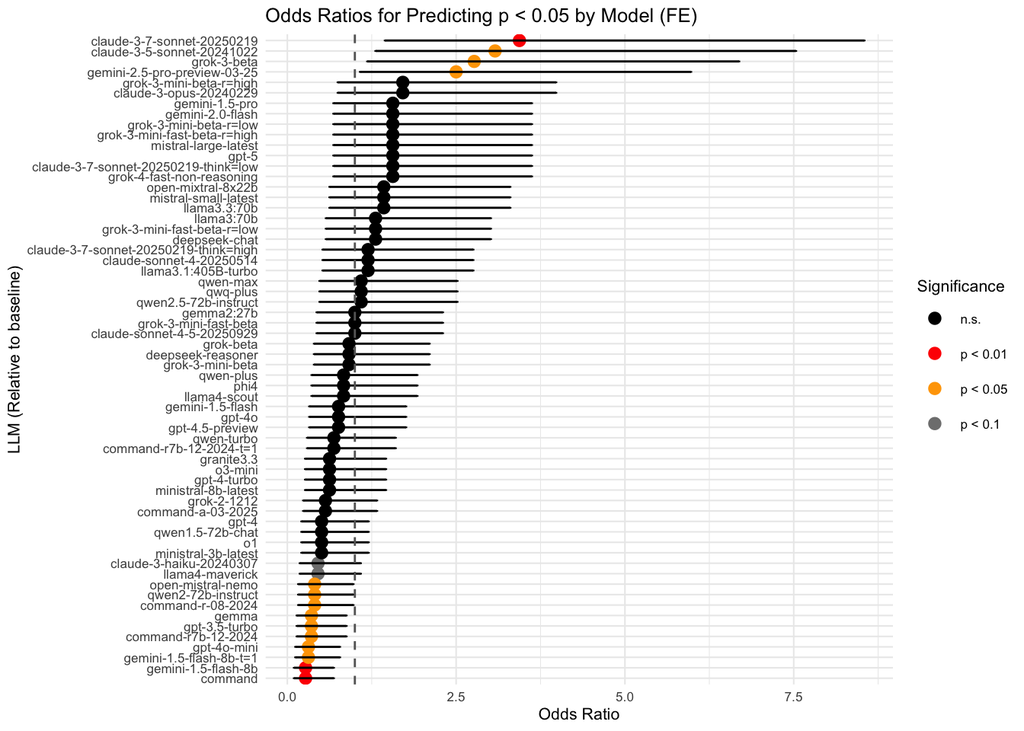

```r
# Plot on fixed effects
coef_df %>%
  ggplot(aes(x = reorder(term, estimate), y = estimate)) +
  geom_point(aes(color = significance), size = 2.4) +
  geom_errorbar(aes(ymin = conf.low, ymax = conf.high), width = 0.15) +
  geom_hline(yintercept = 1,
             linetype = "dashed",
             color = "grey40") +
  coord_flip() +
  labs(
    title = "Odds Ratios for Predicting p < 0.05 by Model (FE)",
    x = "LLM (Relative to baseline)",
    y = "Odds Ratio",
    color = "Significance"
  ) +
  scale_color_manual(
    values = c(
      "p < 0.001" = "darkred",
      "p < 0.01" = "red",
      "p < 0.05" = "orange",
      "p < 0.1" = "grey50",
      "n.s." = "black"  # mapped here
    )
  ) +
  theme_minimal(base_size = 8)
```

### Random Intercept Plot

```r
coef_df <- tidy(
  ri_model,
  effects    = "fixed",
  conf.int   = TRUE,
  exponentiate = TRUE
) %>%
  filter(term != "(Intercept)") %>%

  # exponentiate estimates and CIs
  mutate(
    # estimate  = exp(estimate),
    # conf.low  = exp(conf.low),
    # conf.high = exp(conf.high),
    # std.error = std.error,

    # clean up term names
    term = gsub("model", "", term),

    # add significance
    significance = case_when(
      p.value < 0.001 ~ "p < 0.001",
      p.value < 0.01  ~ "p < 0.01",
      p.value < 0.05  ~ "p < 0.05",
      p.value < 0.1   ~ "p < 0.1",
      TRUE            ~ "n.s."
    )
  ) %>%

  # select and order columns
  select(term,
         estimate,
         std.error,
         conf.low,
         conf.high,
         p.value,
         significance)

coef_df %>%
  arrange(-estimate) %>%
  kable(digits = 3)
```

| term | estimate | std.error | conf.low | conf.high | p.value | significance |
| --- | --- | --- | --- | --- | --- | --- |
| claude-3-7-sonnet-20250219 | 3.863 | 1.819 | 1.535 | 9.724 | 0.004 | p < 0.01 |
| claude-3-5-sonnet-20241022 | 3.425 | 1.593 | 1.377 | 8.523 | 0.008 | p < 0.01 |
| grok-3-beta | 3.053 | 1.405 | 1.239 | 7.522 | 0.015 | p < 0.05 |
| gemini-2.5-pro-preview-03-25 | 2.732 | 1.246 | 1.118 | 6.677 | 0.028 | p < 0.05 |
| claude-3-opus-20240229 | 1.803 | 0.803 | 0.753 | 4.318 | 0.186 | n.s. |
| grok-3-mini-beta-r=high | 1.803 | 0.803 | 0.753 | 4.318 | 0.186 | n.s. |
| gpt-5 | 1.632 | 0.725 | 0.683 | 3.899 | 0.270 | n.s. |
| grok-3-mini-beta-r=low | 1.632 | 0.725 | 0.683 | 3.899 | 0.270 | n.s. |
| gemini-1.5-pro | 1.632 | 0.725 | 0.683 | 3.899 | 0.270 | n.s. |
| grok-3-mini-fast-beta-r=high | 1.632 | 0.725 | 0.683 | 3.899 | 0.270 | n.s. |
| grok-4-fast-non-reasoning | 1.632 | 0.725 | 0.683 | 3.899 | 0.270 | n.s. |
| claude-3-7-sonnet-20250219-think=low | 1.632 | 0.725 | 0.683 | 3.899 | 0.270 | n.s. |
| gemini-2.0-flash | 1.632 | 0.725 | 0.683 | 3.899 | 0.270 | n.s. |
| mistral-large-latest | 1.632 | 0.725 | 0.683 | 3.899 | 0.270 | n.s. |
| llama3.3:70b | 1.479 | 0.656 | 0.620 | 3.528 | 0.377 | n.s. |
| open-mixtral-8x22b | 1.479 | 0.656 | 0.620 | 3.528 | 0.377 | n.s. |
| mistral-small-latest | 1.479 | 0.656 | 0.620 | 3.528 | 0.377 | n.s. |
| deepseek-chat | 1.341 | 0.594 | 0.563 | 3.196 | 0.508 | n.s. |
| llama3:70b | 1.341 | 0.594 | 0.563 | 3.196 | 0.508 | n.s. |
| grok-3-mini-fast-beta-r=low | 1.341 | 0.594 | 0.563 | 3.196 | 0.508 | n.s. |
| llama3.1:405B-turbo | 1.216 | 0.539 | 0.511 | 2.898 | 0.658 | n.s. |
| claude-3-7-sonnet-20250219-think=high | 1.216 | 0.539 | 0.511 | 2.898 | 0.658 | n.s. |
| claude-sonnet-4-20250514 | 1.216 | 0.539 | 0.511 | 2.898 | 0.658 | n.s. |
| qwen-max | 1.103 | 0.489 | 0.463 | 2.630 | 0.825 | n.s. |
| qwen2.5-72b-instruct | 1.103 | 0.489 | 0.463 | 2.630 | 0.825 | n.s. |
| qwq-plus | 1.103 | 0.489 | 0.463 | 2.630 | 0.825 | n.s. |
| claude-sonnet-4-5-20250929 | 1.000 | 0.444 | 0.419 | 2.387 | 1.000 | n.s. |
| gemma2:27b | 1.000 | 0.444 | 0.419 | 2.387 | 1.000 | n.s. |
| grok-3-mini-fast-beta | 1.000 | 0.444 | 0.419 | 2.387 | 1.000 | n.s. |
| grok-beta | 0.906 | 0.403 | 0.379 | 2.167 | 0.824 | n.s. |
| deepseek-reasoner | 0.906 | 0.403 | 0.379 | 2.167 | 0.824 | n.s. |
| grok-3-mini-beta | 0.906 | 0.403 | 0.379 | 2.167 | 0.824 | n.s. |
| phi4 | 0.819 | 0.366 | 0.341 | 1.967 | 0.656 | n.s. |
| llama4-scout | 0.819 | 0.366 | 0.341 | 1.967 | 0.656 | n.s. |
| qwen-plus | 0.819 | 0.366 | 0.341 | 1.967 | 0.656 | n.s. |
| gpt-4.5-preview | 0.740 | 0.332 | 0.307 | 1.783 | 0.502 | n.s. |
| gemini-1.5-flash | 0.740 | 0.332 | 0.307 | 1.783 | 0.502 | n.s. |
| gpt-4o | 0.740 | 0.332 | 0.307 | 1.783 | 0.502 | n.s. |
| command-r7b-12-2024-t=1 | 0.667 | 0.301 | 0.275 | 1.616 | 0.369 | n.s. |
| qwen-turbo | 0.667 | 0.301 | 0.275 | 1.616 | 0.369 | n.s. |
| ministral-8b-latest | 0.599 | 0.273 | 0.246 | 1.461 | 0.260 | n.s. |
| gpt-4-turbo | 0.599 | 0.273 | 0.246 | 1.461 | 0.260 | n.s. |
| granite3.3 | 0.599 | 0.273 | 0.246 | 1.461 | 0.260 | n.s. |
| o3-mini | 0.599 | 0.273 | 0.246 | 1.461 | 0.260 | n.s. |
| grok-2-1212 | 0.537 | 0.246 | 0.218 | 1.319 | 0.175 | n.s. |
| command-a-03-2025 | 0.537 | 0.246 | 0.218 | 1.319 | 0.175 | n.s. |
| gpt-4 | 0.479 | 0.222 | 0.193 | 1.188 | 0.112 | n.s. |
| ministral-3b-latest | 0.479 | 0.222 | 0.193 | 1.188 | 0.112 | n.s. |
| o1 | 0.479 | 0.222 | 0.193 | 1.188 | 0.112 | n.s. |
| qwen1.5-72b-chat | 0.479 | 0.222 | 0.193 | 1.188 | 0.112 | n.s. |
| llama4-maverick | 0.425 | 0.200 | 0.170 | 1.067 | 0.069 | p < 0.1 |
| claude-3-haiku-20240307 | 0.425 | 0.200 | 0.170 | 1.067 | 0.069 | p < 0.1 |
| open-mistral-nemo | 0.375 | 0.179 | 0.148 | 0.955 | 0.040 | p < 0.05 |
| qwen2-72b-instruct | 0.375 | 0.179 | 0.148 | 0.955 | 0.040 | p < 0.05 |
| command-r-08-2024 | 0.375 | 0.179 | 0.148 | 0.955 | 0.040 | p < 0.05 |
| gpt-3.5-turbo | 0.329 | 0.160 | 0.127 | 0.851 | 0.022 | p < 0.05 |
| gemma | 0.329 | 0.160 | 0.127 | 0.851 | 0.022 | p < 0.05 |
| command-r7b-12-2024 | 0.329 | 0.160 | 0.127 | 0.851 | 0.022 | p < 0.05 |
| gemini-1.5-flash-8b-t=1 | 0.286 | 0.141 | 0.108 | 0.754 | 0.011 | p < 0.05 |
| gpt-4o-mini | 0.286 | 0.141 | 0.108 | 0.754 | 0.011 | p < 0.05 |
| command | 0.245 | 0.125 | 0.090 | 0.664 | 0.006 | p < 0.01 |
| gemini-1.5-flash-8b | 0.245 | 0.125 | 0.090 | 0.664 | 0.006 | p < 0.01 |

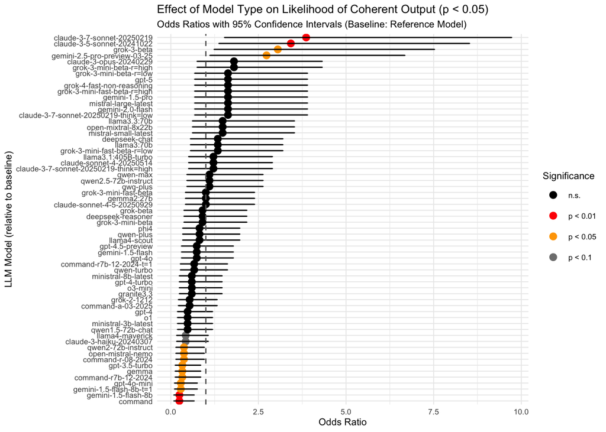

```r
#e.g., Sonnet 3.7 odds of the outcome are 3.8 times higher compared to the reference group (the one that show 1 odds)

##plot with random intercept
coef_df %>%
  ggplot(aes(x = reorder(term, estimate), y = estimate)) +
  geom_point(aes(color = significance), size = 2.4) +
  geom_errorbar(aes(ymin = conf.low, ymax = conf.high), width = 0.15) +
  geom_hline(yintercept = 1,
             linetype = "dashed",
             color = "grey40") +
  coord_flip() +
  labs(
    title = "Effect of Model Type on Likelihood of Coherent Output (p < 0.05)",
    subtitle = "Odds Ratios with 95% Confidence Intervals (Baseline: Reference Model)",
    x = "LLM Model (relative to baseline)",
    y = "Odds Ratio",
    color = "Significance"
  ) +
  scale_color_manual(
    values = c(
      "p < 0.001" = "darkred",
      "p < 0.01" = "red",
      "p < 0.05" = "orange",
      "p < 0.1" = "grey50",
      "n.s." = "black"  # mapped here
    )
  ) +
  theme_minimal(base_size = 8) -> plot

plot
```

# Save results to file

```r
coef_df %>%
  mutate(model = term) %>%
  select(model, estimate, std.error, p.value) %>%
  write_csv(MODELS_RANK)
```